# Calculus1 Expected value and basics of differentiation and integration

ryamada

2017年1月22日

# 1 平均 Average

$$m = \frac{1}{n} \sum_{i=1}^n x_i$$

```r
n <- 10
x <- sample(1:3,n,replace=TRUE)
x
```

```
##  [1] 2 2 2 2 3 3 1 3 2 2
```

```r
mean(x)
```

```
## [1] 2.2
```

```r
1/n * sum(x)
```

```
## [1] 2.2
```

# 2 重み付き平均 Weighted average

$$m_w = \sum_{j=1}^k v_j \times Pr(j)$$

```r
x
```

```
##  [1] 2 2 2 2 3 3 1 3 2 2
```

```r
tabulate(x)
```

```
## [1] 1 6 3
```

```r
w <- tabulate(x)/n
w
```

```
## [1] 0.1 0.6 0.3
```

```r
v <- sort(unique(x))
v
```

```
## [1] 1 2 3
```

```r
mw <- sum(v * w)
mw
```

```
## [1] 2.2
```

# 3 期待値 Expected value

## 3.1 サイコロの目の数の期待値 Expected value of dice

```r
v <- 1:6
p <- rep(1/6,6)
sum(v*p)
```

```
## [1] 3.5
```

出来の悪いサイコロの期待値 Dice in bad condition

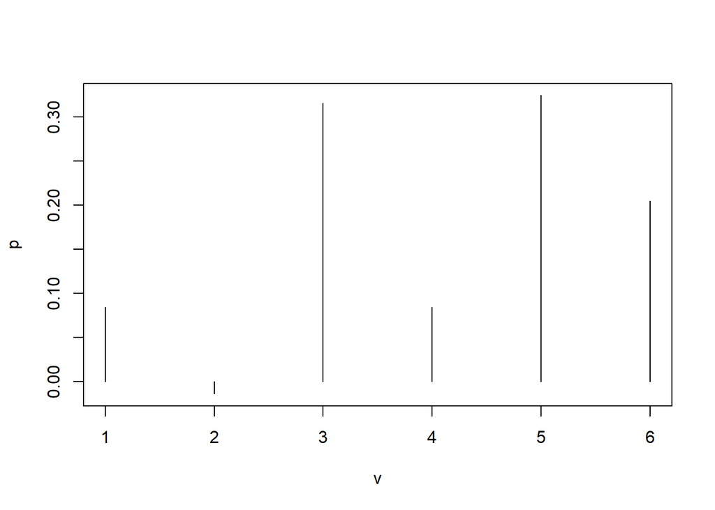

```r
v <- 1:6
p <- rep(1/6,6) + rnorm(6) * 0.1
p <- p/sum(p)
plot(v,p,type="h")
```

```r
p
```

```
## [1]  0.08467227 -0.01393884  0.31571755  0.08413887  0.32464854  0.20476161
```

```r
sum(p)
```

```
## [1] 1
```

```r
sum(v*p)
```

```
## [1] 4.192315
```

## 3.2 二項分布の期待値は $np$ Expected value of binomial distribution : $np$

```r
p0 <- 0.3
n <- 10
i <- 0:n
i.inv <- i[(n+1):1]
choose(n,i)
```

```
##  [1]   1  10  45 120 210 252 210 120  45  10   1
```

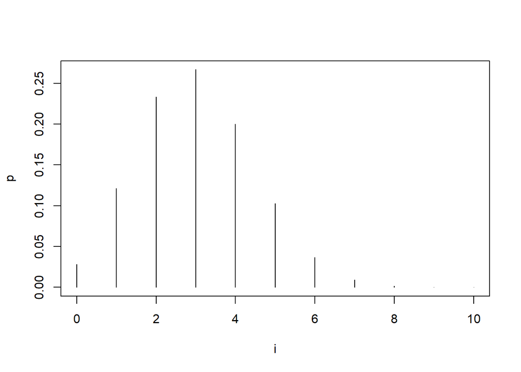

```r
p <- choose(n,i) * p0^i * (1-p0)^i.inv
plot(i,p,type="h")
```

```r
sum(p)
```

```
## [1] 1
```

```r
sum(p*i)
```

```
## [1] 3
```

```r
n * p0
```

```
## [1] 3
```

# 4 ベータ分布

## 4.1 ベータ分布の正規化 Normalization of beta distribution

成功・失敗が、n回とm回だったとき、成功率がpである尤度は n successes and m failures. Likelihood of success rate p is proportional to ;

$$p^n (1-p)^m$$
に比例する。

With $h(n,m)$ below,
$$h(n,m)=\int_0^1 p^n(1-p)^m dp$$

とおけば、the following equaion follows;

$$\int_0^1 \frac{1}{h(n,m)}p^n (1-p)^m dp =1$$
となるから

The following is the likelihood function of success rate p when n successes and m failures.
$$\frac{1}{h(n,m)}p^n (1-p)^m$$

が成功n回、失敗m回のときの成功率pの尤度関数。

$p^n(1-p)^m$が関数の形を決め、$h(n,m)$は積分が1となるように正規化しているので、$h(n,m)$によって(尤度)関数を正規化する、と言う。

$p^n (1-p)^m$ determines its shape and $h(n,m)$ normalizes its integration to 1.

## 4.2 $h(n,m)=\int_0^1 p^n(1-p)^m dp$を計算してみる Calculation of $h(n,m)$

### 4.2.1 n=1, m=0

$$h(1,0) = \int_0^1 p dp$$

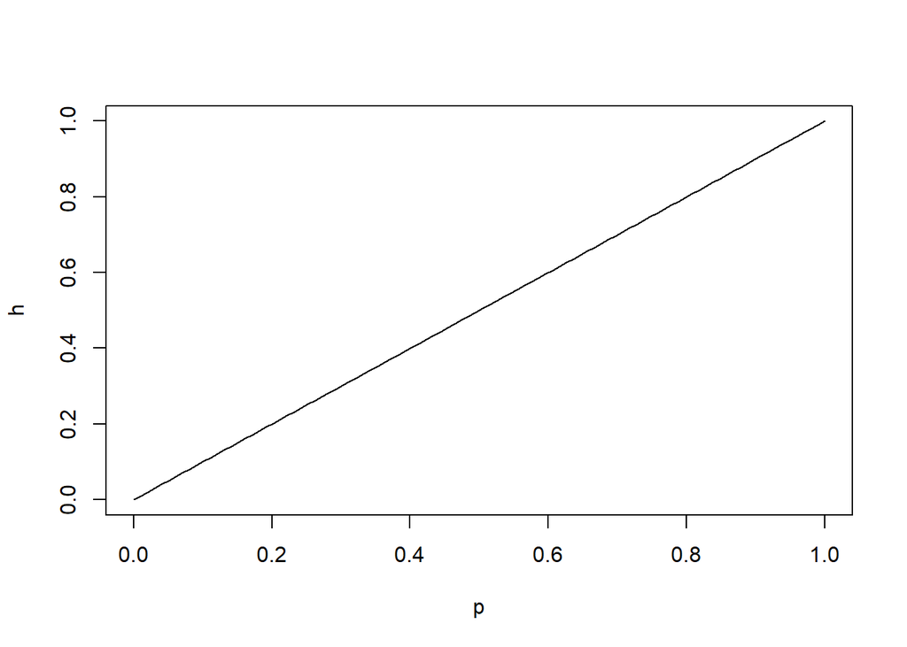

```r
p <- seq(from=0,to=1,length=100)
h <- p
plot(p,h,type="l")
```

$h(1,0)$は面積として計算できる。 Area of $h(1,0)$ is given geometrically.

$$\frac{1}{2} \times 1 \times 1 = \frac{1}{2}$$

積分するなら Integration;

$$\frac{d}{dx} x^2 = 2x\\
\frac{d}{dx} \frac{1}{2} x^2 = x$$
を使って、

$$x^2 + C = \int 2x dx\\
\frac{1}{2} (x^2+C) = \int x dx$$

から、

$$\int_0^1 p dp = [\frac{1}{2} x^2]^1_0 = \frac{1}{2} (1^2-0^2)=\frac{1}{2}$$
となる。

結局、n=1,m=0のときの尤度関数は The likelihood function when n=1 and m=0;
$$\frac{1}{h(1,0)}p^1 (1-p)^0 = \frac{1}{\frac{1}{2}}p = 2p$$

## 4.3 ベータ分布の期待値 Expected value of beta distribution

$n=1,m=0$のときのベータ分布 When$n=1,m=0$, beta distribution is
$$2p$$
その期待値は Its expected value is

$$\int_0^1 (2p) \times p dp = \int_0^1 2p^2 dp = \frac{2}{3}[p^3]^1_0 = \frac{2}{3}$$

# 5 Exercise 1

## 5.1 Exercise 1-1

n=1, m=1の場合、二項観察の尤度関数は Likelihood function for binomial observation n=1 and m=1
$$\frac{1}{h(1,1)} p(1-p) = \frac{1}{h(1,1)}(p-p^2)$$
$$h(1,1) = \int_0^1 p-p^2 dp$$

を求めたい。

$f(x) = x^1 (1-x)^1$ のグラフを描け。Draw $f(x) = x^1(1-x)^1$.

## 5.2 Exercise 1-2

[0,1]区間を、k等分してその小区間ごとの面積を近似的に計算し、その和を[0,1]の範囲の$p-p^2$の面積とみなすこととする。 第i小区間の面積を、長方形の面積とみなして、計算し、kを、1,2,...,100と変化させ、その様子をプロットせよ。ただし、長方形は幅$\frac{1}{k}$、高さはその小区間の両端の$p-p^2$の値の平均値とせよ。

Divide the interval [0,1] into k evenly. Calculate subintervals' area approximately and sum them which is approcimation of the area under the curve. The area of the i-th subinterval should be considered a rectangle whose width is $/frac{1}{k}$ and its hight is the average of the hights of the both ends of the rectangle. Calculate and plot for k=1,2,...,100.

## 5.3 Exercise 1-3

$\frac{d}{dx}x^2 = 2x, \frac{d}{dx}x^3=3x^2$を使って$h(1,1)$を求め、近似で求めた値と比較せよ。

Integrate the function and compare the value with the approximation above.

## 5.5 Exercise 1-5

n=2,m=3の場合の$p^n(1-p)^3$を展開し、n=1,m=1の場合と同様のことをせよ

Do the same for n=2 and m=3.

## 5.6 Exercise 1-6

指数分布の期待値は $\frac{1}{\lambda}$であると言う。このことを、離散的な計算をすることで確認せよ。

The expected value of exponential distribution is $\frac{1}{\lambda}$. Calculate its expected value discretely.

$$Pr(x) = \lambda \times e^{-\lambda x}$$

## 5.7 Exercise 1-6

微分積分の基礎技術 Basic skills of calculus

Go through the every item in the page https://en.wikibooks.org/wiki/Calculus/Differentiation/Basics_of_Differentiation/Solutions#Find_The_Derivative_By_Definition